# 2021 Census: population and household change

Stefano De Sabbata

2022-06-30 13:28:34

```r
library(tidyverse)
library(readxl)
library(nomisr)
library(skimr)
library(ggrepel)
library(ggExtra)
require(scales)
```

This document uses the [population and household estimates](https://www.ons.gov.uk/peoplepopulationandcommunity/populationandmigration/populationestimates/datasets/populationandhouseholdestimatesenglandandwalescensus2021) for England and Wales from the [Census 2021](https://census.gov.uk/) released on 28 June 2022. Source: [Office for National Statistics](https://www.ons.gov.uk/) licensed under the [Open Government Licence v3.0](https://www.nationalarchives.gov.uk/doc/open-government-licence/version/3/).

## Data

The 2021 Census data have been downloaded to the `storage` folder using the script `001-download-data-2022-06-28.R` available in the `000-data` folder.

### Load data

Load 2021 Census data from the `storage` folder.

```r
population_2021 <- readxl::read_xlsx(
    path = "../storage/census2021firstresultsenglandwales1.xlsx",
    sheet = "P01",
    range = "A7:E382"
  ) %>%
  rename(
    area_code = `Area code [note 2]`,
    area_name = `Area name`,
    all_persons_2021 = `All persons`,
    females_2021 = `Females`,
    males_2021 = `Males`
  )

households_2021 <- readxl::read_xlsx(
    path = "../storage/census2021firstresultsenglandwales1.xlsx",
    sheet = "H01",
    range = "A7:C382"
  ) %>%
  rename(
    area_code = `Area code [note 2]`,
    area_name = `Area name`,
    households_2021 = `Number of households with at least one usual resident`
  )
```

### Join and filter LADs

Join the resident population and household tables and keep only the Local Authority Districts (LADs).

```r
population_households_2021 <-
  population_2021 %>%
  full_join(
    households_2021
  ) %>%
  filter(
    str_sub(area_code, start = 1, end = 2) == "E0" |
    str_sub(area_code, start = 1, end = 2) == "W0"
  ) %>%
  mutate(
    area_name = str_remove(area_name, "\\s*\\[.*\\]")
  )
```

### 2011 Census

Retrieve the 2011 Census data for comparison, using [`nomisr`](https://github.com/ropensci/nomisr).

```r
population_2011 <-
  nomis_get_data(
    id = "NM_144_1",       # Usual resident population (KS101EW)
    geography = "TYPE464", # local authorities: district / unitary (prior to April 2015)
    tidy = TRUE
  ) %>%
  filter(
    cell_code %in% c("KS101EW0001", "KS101EW0002", "KS101EW0003") &
    rural_urban == 0 &
    measures_name == "Value"
  ) %>%
  select(geography_code, geography_name, cell_code, obs_value) %>%
  pivot_wider(
    id_cols = c(geography_code, geography_name),
    names_from = cell_code,
    values_from = obs_value
  ) %>%
  rename(
    area_code = geography_code,
    area_name = geography_name,
    all_persons_2011 = KS101EW0001,
    females_2011 = KS101EW0003,
    males_2011 = KS101EW0002
  )
```

```
## Retrieving additional pages 1 of 2
```

```
## Retrieving additional pages 2 of 2
```

```r
households_2011 <-
  nomis_get_data(
    id = "NM_605_1",       # Household composition (KS105EW)
    geography = "TYPE464", # local authorities: district / unitary (prior to April 2015)
    tidy = TRUE
  ) %>%
  filter(
    cell_code %in% c("KS105EW0001") &
    rural_urban == 0 &
    measures_name == "Value"
  ) %>%
  select(geography_code, cell_code, obs_value) %>%
  pivot_wider(
    id_cols = geography_code,
    names_from = cell_code,
    values_from = obs_value
  ) %>%
  rename(
    area_code = geography_code,
    households_2011 = KS105EW0001
  )
```

```
## Retrieving additional pages 1 of 7
```

```
## Retrieving additional pages 2 of 7
```

```
## Retrieving additional pages 3 of 7
```

```
## Retrieving additional pages 4 of 7
```

```
## Retrieving additional pages 5 of 7
```

```
## Retrieving additional pages 6 of 7
```

```
## Retrieving additional pages 7 of 7
```

### Join 2021 and 2011 data

The following changes need to be resolved:

- North Northamptonshire UA comprises the former districts of Corby, East Northamptonshire, Kettering and Wellingborough (Changed 2021).
- West Northamptonshire UA comprises the former districts of Daventry, Northampton, and South Northamptonshire (Changed 2021).
- East Suffolk LA comprises of Suffolk Coastal and Waveney (Changed 2020).
- West Suffolk LA comprises of Forest Heath and St Edmundsbury (Changed 2019).
- Buckinghamshire UA comprises of Aylesbury Vale, Chiltern, South Bucks and Wycombe (Changed 2020).
- Folkestone and Hythe previously named Shepway (Changed 2018).
- Bournemouth, Christchurch and Poole UA comprises the former district of Christchurch and the former UAs of Bournemouth and Poole (Changed 2019).
- Dorset UA comprises the former districts of East Dorset, North Dorset, Purbeck, West Dorset and Weymouth and Portland (Changed 2019).
- Somerset West and Taunton LA comprises of Taunton Deane and West Somerset (Changed 2019).

```r
population_households_2011 <-
  population_2011 %>%
  left_join(households_2011) %>%
  mutate(
    area_name = case_when(

      area_name == "Corby" ~ "North Northamptonshire",
      area_name == "East Northamptonshire" ~ "North Northamptonshire",
      area_name == "Kettering" ~ "North Northamptonshire",
      area_name == "Wellingborough" ~ "North Northamptonshire",

      area_name == "Daventry" ~ "West Northamptonshire",
      area_name == "Northampton" ~ "West Northamptonshire",
      area_name == "South Northamptonshire" ~ "West Northamptonshire",

      area_name == "Suffolk Coastal" ~ "East Suffolk",
      area_name == "Waveney" ~ "East Suffolk",

      area_name == "Forest Heath" ~ "West Suffolk",
      area_name == "St Edmundsbury" ~ "West Suffolk",

      area_name == "Aylesbury Vale" ~ "Buckinghamshire",
      area_name == "Chiltern" ~ "Buckinghamshire",
      area_name == "South Bucks" ~ "Buckinghamshire",
      area_name == "Wycombe" ~ "Buckinghamshire",

      area_name == "Shepway" ~ "Folkestone and Hythe",

      area_name == "Christchurch" ~ "Bournemouth, Christchurch and Poole",
      area_name == "Bournemouth" ~ "Bournemouth, Christchurch and Poole",
      area_name == "Poole" ~ "Bournemouth, Christchurch and Poole",

      area_name == "East Dorset" ~ "Dorset",
      area_name == "North Dorset" ~ "Dorset",
      area_name == "Purbeck" ~ "Dorset",
      area_name == "West Dorset" ~ "Dorset",
      area_name == "Weymouth and Portland" ~ "Dorset",

      area_name == "Taunton Deane" ~ "Somerset West and Taunton",
      area_name == "West Somerset" ~ "Somerset West and Taunton",

      TRUE ~ area_name
    )
  ) %>%
  mutate(
    area_code = case_when(
      area_name == "North Northamptonshire" ~ "E06000061", # E06000061  North Northamptonshire [note 3]
      area_name == "West Northamptonshire" ~ "E06000062", # E06000062   West Northamptonshire [note 4]
      area_name == "East Suffolk" ~ "E07000244", # E07000244    East Suffolk [note 5]
      area_name == "West Suffolk" ~ "E07000245", # E07000245    West Suffolk [note 6]
      area_name == "Buckinghamshire" ~ "E06000060", # E06000060 Buckinghamshire [note 7]
      area_name == "Folkestone and Hythe" ~ "E07000112", # E07000112    Folkestone and Hythe [note 8]
      area_name == "Bournemouth, Christchurch and Poole" ~ "E06000058", # E06000058 Bournemouth, Christchurch and Poole [note 9]
      area_name == "Dorset" ~ "E06000059", # E06000059  Dorset [note 10]
      area_name == "Somerset West and Taunton" ~ "E07000246", # E07000246   Somerset West and Taunton [note 11]
      TRUE ~ area_code
    )
  ) %>%
  group_by(area_code, area_name) %>%
  summarise(
    across(
      all_persons_2011:households_2011,
      ~ sum(.x)
    )
  )
population_households <-
  population_households_2021 %>%
  left_join(
    population_households_2011 %>%
      select(-area_name)
  )
```

### Data summary

```r
population_households %>%
  skim()
```

Data summary

| Name | Piped data |
| --- | --- |
| Number of rows | 331 |
| Number of columns | 10 |
| _______________________ |  |
| Column type frequency: |  |
| character | 2 |
| numeric | 8 |
| ________________________ |  |
| Group variables | None |

**Variable type: character**

| skim_variable | n_missing | complete_rate | min | max | empty | n_unique | whitespace |
| --- | --- | --- | --- | --- | --- | --- | --- |
| area_code | 0 | 1 | 9 | 9 | 0 | 331 | 0 |
| area_name | 0 | 1 | 4 | 35 | 0 | 331 | 0 |

**Variable type: numeric**

| skim_variable | n_missing | complete_rate | mean | sd | p0 | p25 | p50 | p75 | p100 | hist |
| --- | --- | --- | --- | --- | --- | --- | --- | --- | --- | --- |
| all_persons_2021 | 0 | 1 | 180052.87 | 121426.02 | 2100 | 103300.0 | 141900 | 217800.0 | 1144900 | ▇▂▁▁▁ |
| females_2021 | 0 | 1 | 91905.74 | 61934.36 | 1100 | 52600.0 | 72700 | 112400.0 | 584300 | ▇▂▁▁▁ |
| males_2021 | 0 | 1 | 88146.22 | 59506.04 | 1000 | 50750.0 | 69500 | 106550.0 | 560500 | ▇▂▁▁▁ |
| households_2021 | 0 | 1 | 74874.62 | 48468.40 | 900 | 44600.0 | 60000 | 92950.0 | 423500 | ▇▂▁▁▁ |
| all_persons_2011 | 0 | 1 | 169413.63 | 113397.40 | 2203 | 97738.5 | 133788 | 207915.0 | 1073045 | ▇▂▁▁▁ |
| males_2011 | 0 | 1 | 83303.25 | 55897.52 | 1102 | 48093.5 | 65655 | 103421.5 | 527806 | ▇▂▁▁▁ |
| females_2011 | 0 | 1 | 86110.38 | 57526.05 | 1101 | 49865.0 | 68252 | 105521.0 | 545239 | ▇▂▁▁▁ |
| households_2011 | 0 | 1 | 70592.28 | 46193.73 | 989 | 41498.0 | 55703 | 88887.5 | 410736 | ▇▂▁▁▁ |

## Visualisation

### Visualisation: code

Exploring the relationship between resident population and household change.

```r
scatterplot_population_households_2011 <-
  population_households %>%
  mutate(
    plot_label = case_when(
      area_name == "Leicester" ~ "Leicester",
      area_name == "Newham" ~ "Newham",
      area_name == "Redbridge" ~ "Redbridge",
      area_name == "Barking and Dagenham" ~ "Barking and\nDagenham",
      area_name == "Slough" ~ "Slough",
      TRUE ~ ""
    ),
    plot_fill = case_when(
      area_name == "Leicester" ~ "Leicester",
      area_name == "Blaby" ~ "Leicestershire",
      area_name == "Charnwood" ~ "Leicestershire",
      area_name == "Harborough" ~ "Leicestershire",
      area_name == "Hinckley and Bosworth" ~ "Leicestershire",
      area_name == "Melton" ~ "Leicestershire",
      area_name == "North West Leicestershire" ~ "Leicestershire",
      area_name == "Oadby and Wigston" ~ "Leicestershire",
      TRUE ~ "Other"
    )
  ) %>%
  arrange(desc(plot_fill)) %>%
  ggplot(
    aes(
      x = all_persons_2011,
      y = households_2011,
      fill = plot_fill
    )
  ) +
  geom_point(shape = 21, colour = "#666666") +
  geom_text_repel(
    aes(label = plot_label),
    colour = "#666666",
    size = 3,
    force = 0.1,
    force_pull = 0.01,
    box.padding = 0.5,
    min.segment.length = 0,
    segment.curvature = -0.1,
    max.overlaps = Inf
  ) +
  scale_fill_manual(
    values = c(
      "Leicester" = "#377eb8",
      "Leicestershire" = "#e41a1c",
      "Other" = "#999999"
    )
  ) +
  # scale_x_log10(labels = comma) +
  # scale_y_log10(labels = comma) +
  scale_x_continuous(labels = comma, limits = c(-30000, 1200000)) +
  scale_y_continuous(labels = comma, limits = c(-10000, 450000)) +
  xlab("All persons") +
  ylab("Households") +
  guides(
   fill = guide_legend(
     title = "Area"
   )
  ) +
  labs(
    title = "Comparing resident population and households",
    subtitle = "2011 Census, per Local Authority District\nin England and Wales",
    caption = "\nby Stefano De Sabbata, University of Leicester\nSource: Office for National Statistics licensed under the Open Government Licence"
  ) +
  theme_bw() +
  theme(legend.position = "bottom")


scatterplot_population_households_2021 <-
  population_households %>%
  mutate(
    plot_label = case_when(
      area_name == "Leicester" ~ "Leicester",
      area_name == "Newham" ~ "Newham",
      area_name == "Redbridge" ~ "Redbridge",
      area_name == "Barking and Dagenham" ~ "Barking and\nDagenham",
      area_name == "Slough" ~ "Slough",
      TRUE ~ ""
    ),
    plot_fill = case_when(
      area_name == "Leicester" ~ "Leicester",
      area_name == "Blaby" ~ "Leicestershire",
      area_name == "Charnwood" ~ "Leicestershire",
      area_name == "Harborough" ~ "Leicestershire",
      area_name == "Hinckley and Bosworth" ~ "Leicestershire",
      area_name == "Melton" ~ "Leicestershire",
      area_name == "North West Leicestershire" ~ "Leicestershire",
      area_name == "Oadby and Wigston" ~ "Leicestershire",
      TRUE ~ "Other"
    )
  ) %>%
  arrange(desc(plot_fill)) %>%
  ggplot(
    aes(
      x = all_persons_2021,
      y = households_2021,
      fill = plot_fill
    )
  ) +
  geom_point(shape = 21, colour = "#666666") +
  geom_text_repel(
    aes(label = plot_label),
    colour = "#666666",
    size = 3,
    force = 0.1,
    force_pull = 0.01,
    box.padding = 0.5,
    min.segment.length = 0,
    segment.curvature = -0.1,
    max.overlaps = Inf
  ) +
  scale_fill_manual(
    values = c(
      "Leicester" = "#377eb8",
      "Leicestershire" = "#e41a1c",
      "Other" = "#999999"
    )
  ) +
  # scale_x_log10(labels = comma) +
  # scale_y_log10(labels = comma) +
  scale_x_continuous(labels = comma, limits = c(-30000, 1200000)) +
  scale_y_continuous(labels = comma, limits = c(-10000, 450000)) +
  xlab("All persons") +
  ylab("Households") +
  guides(
   fill = guide_legend(
     title = "Area"
   )
  ) +
  labs(
    title = "Comparing resident population and households",
    subtitle = "2021 Census, per Local Authority District\nin England and Wales",
    caption = "\nby Stefano De Sabbata, University of Leicester\nSource: Office for National Statistics licensed under the Open Government Licence"
  ) +
  theme_bw() +
  theme(legend.position = "bottom")
```

```r
scatterplot_population_households_change <-
  population_households %>%
  mutate(
    plot_label = case_when(
      area_name == "Leicester" ~ "Leicester",
      area_name == "Barking and Dagenham" ~ "Barking and\nDagenham",
      area_name == "Slough" ~ "Slough",
      area_name == "Newham" ~ "Newham",
      area_name == "Redbridge" ~ "Redbridge",
      TRUE ~ ""
    ),
    plot_fill = case_when(
      area_name == "Leicester" ~ "Leicester",
      area_name == "Blaby" ~ "Leicestershire",
      area_name == "Charnwood" ~ "Leicestershire",
      area_name == "Harborough" ~ "Leicestershire",
      area_name == "Hinckley and Bosworth" ~ "Leicestershire",
      area_name == "Melton" ~ "Leicestershire",
      area_name == "North West Leicestershire" ~ "Leicestershire",
      area_name == "Oadby and Wigston" ~ "Leicestershire",
      TRUE ~ "Other"
    )
  ) %>%
  arrange(desc(plot_fill)) %>%
  ggplot(
    aes(
      x = (((all_persons_2021 - all_persons_2011) / all_persons_2011) * 100),
      y = (((households_2021 - households_2011) / households_2011) * 100),
      fill = plot_fill
    )
  ) +
  geom_point(shape = 21, colour = "#666666") +
  geom_text_repel(
    aes(label = plot_label),
    colour = "#666666",
    size = 3,
    force = 1,
    force_pull = 0.1,
    box.padding = 0.5,
    min.segment.length = 0,
    segment.curvature = -0.1
  ) +
  geom_abline(
    slope = 1,
    intercept = 0
  ) +
  scale_fill_manual(
    values = c(
      "Leicester" = "#377eb8",
      "Leicestershire" = "#e41a1c",
      "Other" = "#999999"
    )
  ) +
  xlab("All persons (percentage change)") +
  ylab("Households (percentage change)") +
  guides(
   fill = guide_legend(
     title = "Area"
   )
  ) +
  labs(
    title = "Comparing resident population and households change",
    subtitle = "between the 2011 and 2021 Census, per Local Authority District\nin England and Wales",
    caption = "\nby Stefano De Sabbata, University of Leicester\nSource: Office for National Statistics licensed under the Open Government Licence"
  ) +
  coord_fixed(ratio = 1) +
  theme_bw() +
  theme(legend.position = "bottom")
```

```r
scatterplot_population_households_change_leics <-
  population_households %>%
  mutate(
    plot_label = case_when(
      area_name == "Leicester" ~ "Leicester",
      area_name == "Blaby" ~ "Blaby",
      area_name == "Charnwood" ~ "Charnwood",
      area_name == "Harborough" ~ "Harborough",
      area_name == "Hinckley and Bosworth" ~ "Hinckley and\nBosworth",
      area_name == "Melton" ~ "Melton",
      area_name == "North West Leicestershire" ~ "North West\nLeicestershire",
      area_name == "Oadby and Wigston" ~ "Oadby and Wigston",
      TRUE ~ ""
    ),
    plot_fill = case_when(
      area_name == "Leicester" ~ "Leicester",
      area_name == "Blaby" ~ "Leicestershire",
      area_name == "Charnwood" ~ "Leicestershire",
      area_name == "Harborough" ~ "Leicestershire",
      area_name == "Hinckley and Bosworth" ~ "Leicestershire",
      area_name == "Melton" ~ "Leicestershire",
      area_name == "North West Leicestershire" ~ "Leicestershire",
      area_name == "Oadby and Wigston" ~ "Leicestershire",
      TRUE ~ "Other"
    ),
    plot_alpha = case_when(
      area_name == "Leicester" ~ 1.0,
      area_name == "Blaby" ~ 1.0,
      area_name == "Charnwood" ~ 1.0,
      area_name == "Harborough" ~ 1.0,
      area_name == "Hinckley and Bosworth" ~ 1.0,
      area_name == "Melton" ~ 1.0,
      area_name == "North West Leicestershire" ~ 1.0,
      area_name == "Oadby and Wigston" ~ 1.0,
      TRUE ~ 0.4
    )
  ) %>%
  arrange(desc(plot_fill)) %>%
  ggplot(
    aes(
      x = (((all_persons_2021 - all_persons_2011) / all_persons_2011) * 100),
      y = (((households_2021 - households_2011) / households_2011) * 100),
      fill = plot_fill,
      alpha = plot_alpha
    )
  ) +
  geom_point(shape = 21, colour = "#666666") +
  geom_text_repel(
    aes(label = plot_label),
    colour = "#666666",
    size = 3,
    force = 5,
    force_pull = 0,
    box.padding = 0.5,
    min.segment.length = 0,
    segment.curvature = -0.1,
    max.overlaps = Inf
  ) +
  geom_abline(
    slope = 1,
    intercept = 0
  ) +
  scale_fill_manual(
    values = c(
      "Leicester" = "#377eb8",
      "Leicestershire" = "#e41a1c",
      "Other" = "#CCCCCC"
    )
  ) +
  xlab("All persons (percentage change)") +
  ylab("Households (percentage change)") +
  guides(
   fill = guide_legend(
     title = "Area"
   ),
   alpha = FALSE
  ) +
  labs(
    title = "Comparing resident population and households change",
    subtitle = "between the 2011 and 2021 Census, per Local Authority District\nin England and Wales",
    caption = "\nby Stefano De Sabbata, University of Leicester\nSource: Office for National Statistics licensed under the Open Government Licence"
  ) +
  coord_fixed(ratio = 1) +
  theme_bw() +
  theme(legend.position = "bottom")
scatterplot_population_households_change_colour <-
  population_households %>%
  mutate(
    plot_label = case_when(
      area_name == "Leicester" ~ "Leicester",
      area_name == "Barking and Dagenham" ~ "Barking and\nDagenham",
      area_name == "Slough" ~ "Slough",
      area_name == "Newham" ~ "Newham",
      area_name == "Redbridge" ~ "Redbridge",
      TRUE ~ ""
    )
  ) %>%
  ggplot(
    aes(
      x = (((all_persons_2021 - all_persons_2011) / all_persons_2011) * 100),
      y = (((households_2021 - households_2011) / households_2011) * 100),
      fill = -1 * ((
          (-1 * (all_persons_2021 - all_persons_2011) / all_persons_2011) +
          (1 * (households_2021 - households_2011) / households_2011)
        ) / sqrt(2))
    )
  ) +
  geom_point(shape = 21, colour = "#666666") +
  geom_text_repel(
    aes(label = plot_label),
    colour = "#666666",
    size = 3,
    force = 1,
    force_pull = 0.1,
    box.padding = 0.5,
    min.segment.length = 0,
    segment.curvature = -0.1
  ) +
  geom_abline(
    slope = 1,
    intercept = 0
  ) +
  scale_fill_distiller(palette = "PuOr")+
  xlab("All persons (percentage change)") +
  ylab("Households (percentage change)") +
  guides(
   fill = guide_legend(
     title = "Area"
   )
  ) +
  labs(
    title = "Comparing resident population and households change",
    subtitle = "between the 2011 and 2021 Census, per Local Authority District\nin England and Wales",
    caption = "\nby Stefano De Sabbata, University of Leicester\nSource: Office for National Statistics licensed under the Open Government Licence"
  ) +
  coord_fixed(ratio = 1) +
  theme_bw() +
  theme(legend.position = "bottom")
```

```r
marginal_population_households_change <-
  ggMarginal(
    scatterplot_population_households_change,
    type = "histogram",
    fill = "#666666"
  )
```

### Visualisation: plots

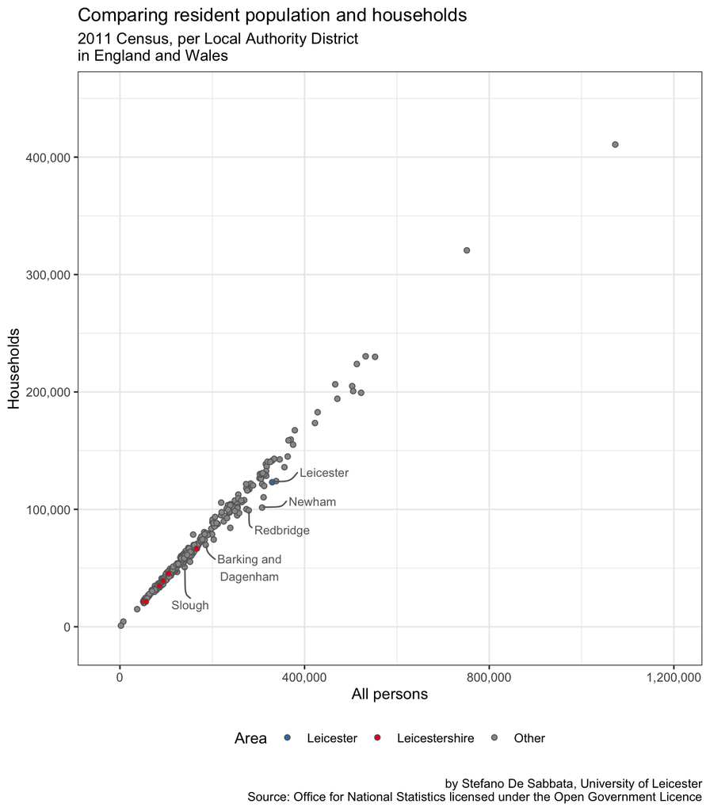

```r
print(scatterplot_population_households_2011)
```

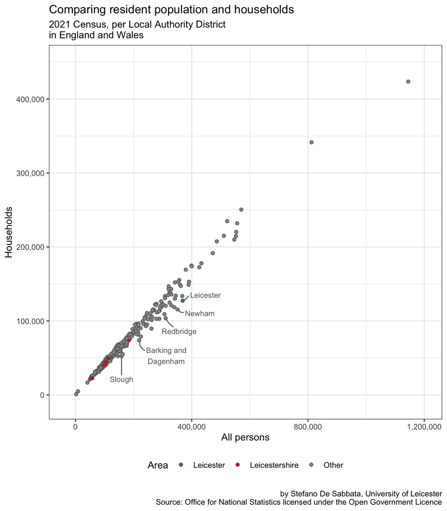

```r
print(scatterplot_population_households_2021)
```

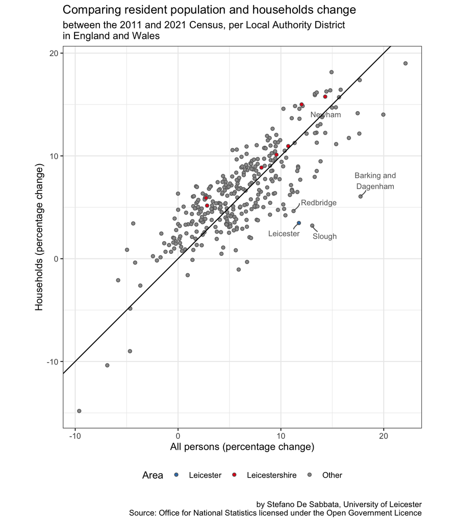

```r
print(scatterplot_population_households_change)
```

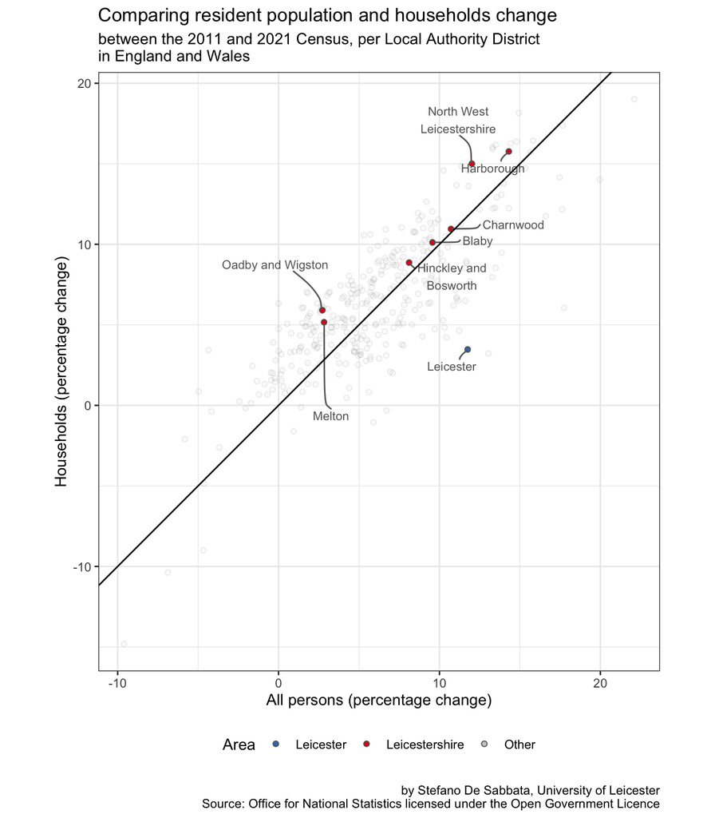

```r
print(scatterplot_population_households_change_leics)
```

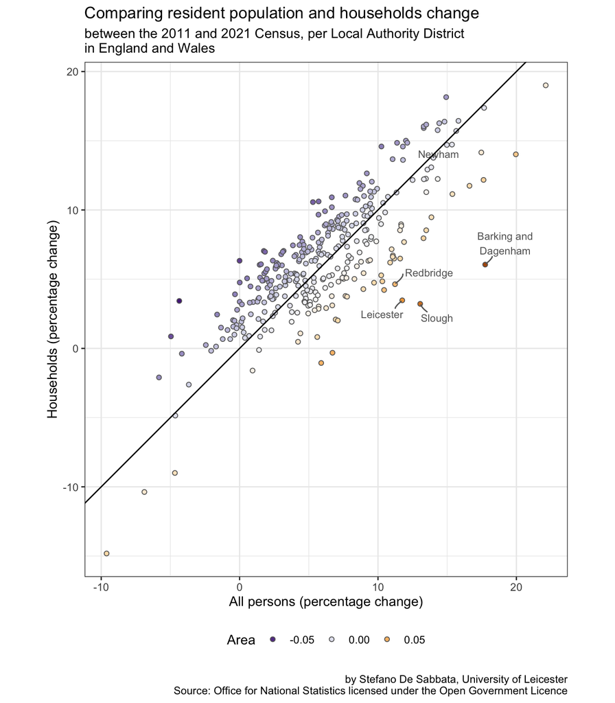

```r
print(scatterplot_population_households_change_colour)
```

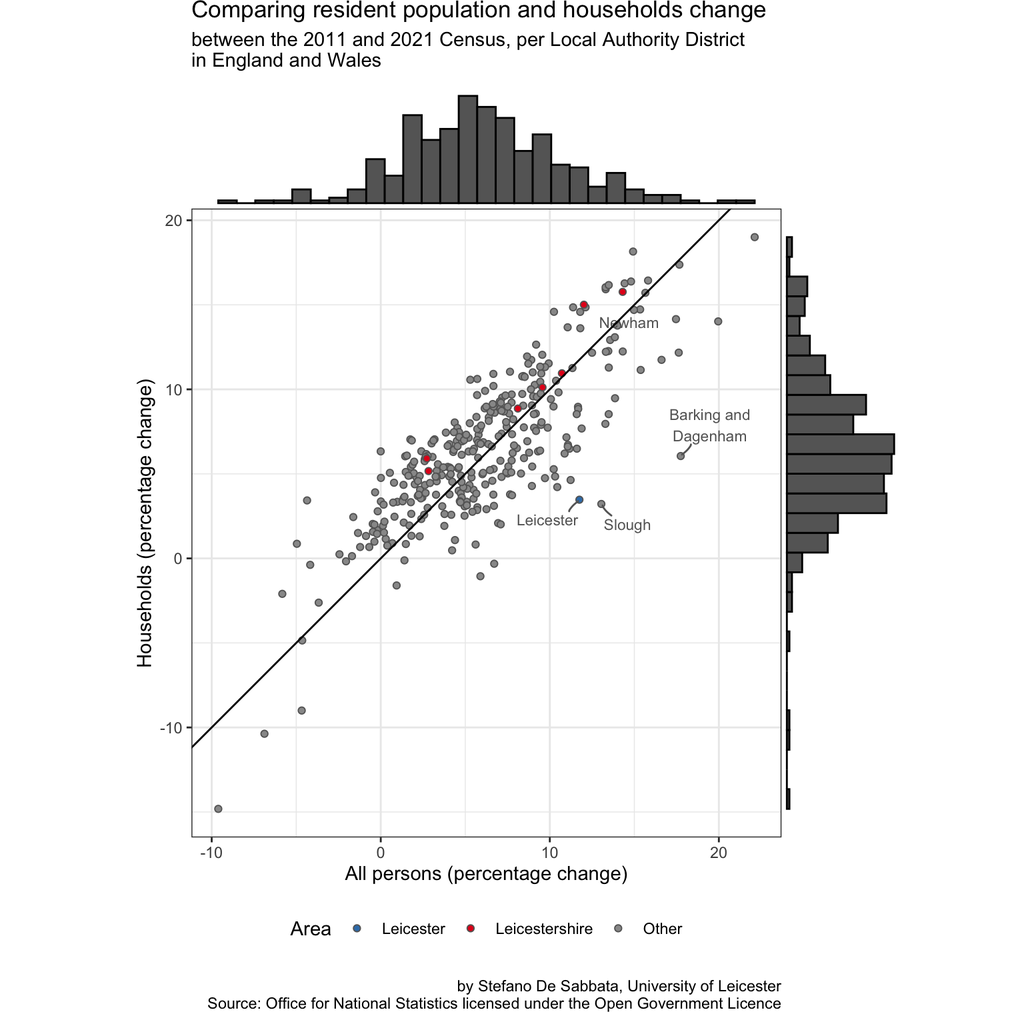

```r
print(marginal_population_households_change)
```